# Primeiros Passos em R

Lucas Laguardia

18/03/2026

O objetivo desse exercício é apresentar municípios que possuem a indústria extrativa como destaque e traçar o perfil dos vínculos empregatícios da atividade econômica extrativa das Unidades da Federação selecionada, respondendo às seguintes perguntas (Utilize o ano de 2020 ou 2021 como referência):

# Questão 1

*Unidade de Federação:* Espírito Santo *Ano:* 2021

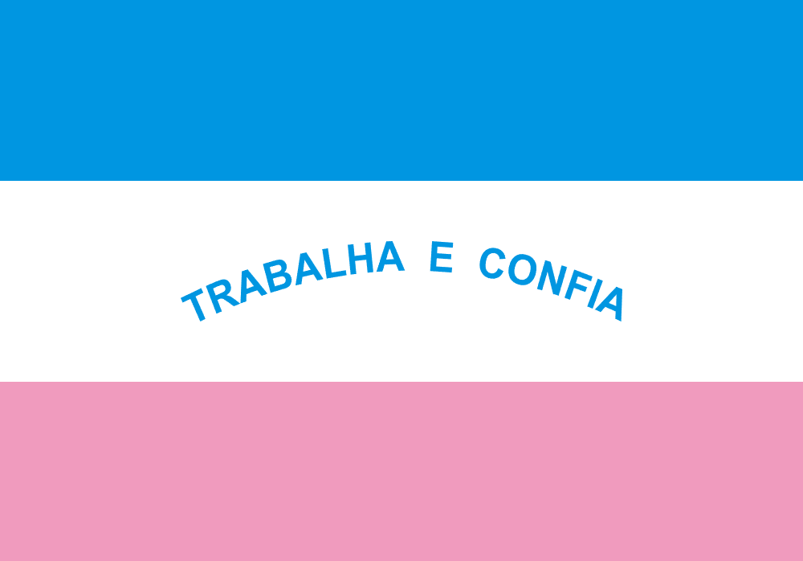

### 1.1 Quais os municípios que apresentaram a indústria extrativa como a principal, a segunda ou a terceira mais importante atividade econômica?

**Resposta:** Agua Doce do Norte, Anchieta, Vila Pavao

Tabela 1 - Atividades econômicas com mais vínculos por município - Espírito Santo (2021)

| Município | 1º | 2º | 3º |
| --- | --- | --- | --- |
| Afonso Claudio | Administração Pública, Defesa e Seguridade Social | Comércio, Reparação de Veículos Automotores e Motocicletas | Indústrias de Transformação |
| Agua Doce do Norte | Administração Pública, Defesa e Seguridade Social | Comércio, Reparação de Veículos Automotores e Motocicletas | Indústrias Extrativas |
| Aguia Branca | Administração Pública, Defesa e Seguridade Social | Comércio, Reparação de Veículos Automotores e Motocicletas | Saúde Humana e Serviços Sociais |
| Alegre | Comércio, Reparação de Veículos Automotores e Motocicletas | Administração Pública, Defesa e Seguridade Social | Atividades Administrativas e Serviços Complementares |
| Alfredo Chaves | Administração Pública, Defesa e Seguridade Social | Comércio, Reparação de Veículos Automotores e Motocicletas | Transporte, Armazenagem e Correio |
| Alto Rio Novo | Administração Pública, Defesa e Seguridade Social | Comércio, Reparação de Veículos Automotores e Motocicletas | Agricultura, Pecuária, Produção Florestal, Pesca e AqÜIcultura |
| Anchieta | Administração Pública, Defesa e Seguridade Social | Comércio, Reparação de Veículos Automotores e Motocicletas | Indústrias Extrativas |
| Apiaca | Administração Pública, Defesa e Seguridade Social | Comércio, Reparação de Veículos Automotores e Motocicletas | Agricultura, Pecuária, Produção Florestal, Pesca e AqÜIcultura |
| Aracruz | Indústrias de Transformação | Construção | Comércio, Reparação de Veículos Automotores e Motocicletas |
| Atilio Vivacqua | Indústrias de Transformação | Administração Pública, Defesa e Seguridade Social | Comércio, Reparação de Veículos Automotores e Motocicletas |
| Baixo Guandu | Administração Pública, Defesa e Seguridade Social | Comércio, Reparação de Veículos Automotores e Motocicletas | Indústrias de Transformação |
| Barra de Sao Francisco | Comércio, Reparação de Veículos Automotores e Motocicletas | Administração Pública, Defesa e Seguridade Social | Indústrias de Transformação |
| Boa Esperanca | Administração Pública, Defesa e Seguridade Social | Comércio, Reparação de Veículos Automotores e Motocicletas | Agricultura, Pecuária, Produção Florestal, Pesca e AqÜIcultura |
| Bom Jesus do Norte | Administração Pública, Defesa e Seguridade Social | Comércio, Reparação de Veículos Automotores e Motocicletas | Indústrias de Transformação |
| Brejetuba | Administração Pública, Defesa e Seguridade Social | Agricultura, Pecuária, Produção Florestal, Pesca e AqÜIcultura | Comércio, Reparação de Veículos Automotores e Motocicletas |
| Cachoeiro de Itapemirim | Comércio, Reparação de Veículos Automotores e Motocicletas | Indústrias de Transformação | Administração Pública, Defesa e Seguridade Social |
| Cariacica | Comércio, Reparação de Veículos Automotores e Motocicletas | Transporte, Armazenagem e Correio | Administração Pública, Defesa e Seguridade Social |
| Castelo | Indústrias de Transformação | Comércio, Reparação de Veículos Automotores e Motocicletas | Administração Pública, Defesa e Seguridade Social |
| Colatina | Comércio, Reparação de Veículos Automotores e Motocicletas | Indústrias de Transformação | Administração Pública, Defesa e Seguridade Social |
| Conceicao da Barra | Administração Pública, Defesa e Seguridade Social | Atividades Financeiras, de Seguros e Serviços Relacionados | Agricultura, Pecuária, Produção Florestal, Pesca e AqÜIcultura |
| Conceicao do Castelo | Comércio, Reparação de Veículos Automotores e Motocicletas | Administração Pública, Defesa e Seguridade Social | Agricultura, Pecuária, Produção Florestal, Pesca e AqÜIcultura |
| Divino de Sao Lourenco | Administração Pública, Defesa e Seguridade Social | Comércio, Reparação de Veículos Automotores e Motocicletas | Indústrias de Transformação |
| Domingos Martins | Comércio, Reparação de Veículos Automotores e Motocicletas | Administração Pública, Defesa e Seguridade Social | Indústrias de Transformação |
| Dores do Rio Preto | Comércio, Reparação de Veículos Automotores e Motocicletas | Administração Pública, Defesa e Seguridade Social | Indústrias de Transformação |
| Ecoporanga | Administração Pública, Defesa e Seguridade Social | Comércio, Reparação de Veículos Automotores e Motocicletas | Agricultura, Pecuária, Produção Florestal, Pesca e AqÜIcultura |
| Fundao | Administração Pública, Defesa e Seguridade Social | Comércio, Reparação de Veículos Automotores e Motocicletas | Indústrias de Transformação |
| Governador Lindenberg | Administração Pública, Defesa e Seguridade Social | Comércio, Reparação de Veículos Automotores e Motocicletas | Indústrias de Transformação |
| Guacui | Comércio, Reparação de Veículos Automotores e Motocicletas | Administração Pública, Defesa e Seguridade Social | Indústrias de Transformação |
| Guarapari | Comércio, Reparação de Veículos Automotores e Motocicletas | Administração Pública, Defesa e Seguridade Social | Atividades Administrativas e Serviços Complementares |
| Ibatiba | Comércio, Reparação de Veículos Automotores e Motocicletas | Administração Pública, Defesa e Seguridade Social | Indústrias de Transformação |
| Ibiracu | Atividades Administrativas e Serviços Complementares | Indústrias de Transformação | Comércio, Reparação de Veículos Automotores e Motocicletas |
| Ibitirama | Administração Pública, Defesa e Seguridade Social | Comércio, Reparação de Veículos Automotores e Motocicletas | Indústrias de Transformação |
| Iconha | Transporte, Armazenagem e Correio | Comércio, Reparação de Veículos Automotores e Motocicletas | Administração Pública, Defesa e Seguridade Social |
| Irupi | Administração Pública, Defesa e Seguridade Social | Comércio, Reparação de Veículos Automotores e Motocicletas | Saúde Humana e Serviços Sociais |
| Itaguacu | Administração Pública, Defesa e Seguridade Social | Comércio, Reparação de Veículos Automotores e Motocicletas | Indústrias de Transformação |
| Itapemirim | Administração Pública, Defesa e Seguridade Social | Indústrias de Transformação | Comércio, Reparação de Veículos Automotores e Motocicletas |
| Itarana | Construção | Comércio, Reparação de Veículos Automotores e Motocicletas | Administração Pública, Defesa e Seguridade Social |
| Iuna | Comércio, Reparação de Veículos Automotores e Motocicletas | Administração Pública, Defesa e Seguridade Social | Saúde Humana e Serviços Sociais |
| Jaguare | Administração Pública, Defesa e Seguridade Social | Agricultura, Pecuária, Produção Florestal, Pesca e AqÜIcultura | Comércio, Reparação de Veículos Automotores e Motocicletas |
| Jeronimo Monteiro | Administração Pública, Defesa e Seguridade Social | Comércio, Reparação de Veículos Automotores e Motocicletas | Indústrias de Transformação |
| Joao Neiva | Indústrias de Transformação | Administração Pública, Defesa e Seguridade Social | Comércio, Reparação de Veículos Automotores e Motocicletas |
| Laranja da Terra | Administração Pública, Defesa e Seguridade Social | Comércio, Reparação de Veículos Automotores e Motocicletas | Indústrias de Transformação |
| Linhares | Indústrias de Transformação | Comércio, Reparação de Veículos Automotores e Motocicletas | Administração Pública, Defesa e Seguridade Social |
| Mantenopolis | Administração Pública, Defesa e Seguridade Social | Comércio, Reparação de Veículos Automotores e Motocicletas | Outras Atividades de Serviços |
| Marataizes | Administração Pública, Defesa e Seguridade Social | Comércio, Reparação de Veículos Automotores e Motocicletas | Atividades Profissionais, Científicas e Técnicas |
| Marechal Floriano | Indústrias de Transformação | Administração Pública, Defesa e Seguridade Social | Transporte, Armazenagem e Correio |
| Marilandia | Indústrias de Transformação | Administração Pública, Defesa e Seguridade Social | Comércio, Reparação de Veículos Automotores e Motocicletas |
| Mimoso do Sul | Administração Pública, Defesa e Seguridade Social | Comércio, Reparação de Veículos Automotores e Motocicletas | Indústrias de Transformação |
| Montanha | Administração Pública, Defesa e Seguridade Social | Agricultura, Pecuária, Produção Florestal, Pesca e AqÜIcultura | Comércio, Reparação de Veículos Automotores e Motocicletas |
| Mucurici | Administração Pública, Defesa e Seguridade Social | Agricultura, Pecuária, Produção Florestal, Pesca e AqÜIcultura | Comércio, Reparação de Veículos Automotores e Motocicletas |
| Muniz Freire | Comércio, Reparação de Veículos Automotores e Motocicletas | Administração Pública, Defesa e Seguridade Social | Indústrias de Transformação |
| Muqui | Administração Pública, Defesa e Seguridade Social | Comércio, Reparação de Veículos Automotores e Motocicletas | Agricultura, Pecuária, Produção Florestal, Pesca e AqÜIcultura |
| Nova Venecia | Comércio, Reparação de Veículos Automotores e Motocicletas | Administração Pública, Defesa e Seguridade Social | Indústrias de Transformação |
| Pancas | Administração Pública, Defesa e Seguridade Social | Comércio, Reparação de Veículos Automotores e Motocicletas | Agricultura, Pecuária, Produção Florestal, Pesca e AqÜIcultura |
| Pedro Canario | Administração Pública, Defesa e Seguridade Social | Construção | Comércio, Reparação de Veículos Automotores e Motocicletas |
| Pinheiros | Agricultura, Pecuária, Produção Florestal, Pesca e AqÜIcultura | Administração Pública, Defesa e Seguridade Social | Comércio, Reparação de Veículos Automotores e Motocicletas |
| Piuma | Comércio, Reparação de Veículos Automotores e Motocicletas | Administração Pública, Defesa e Seguridade Social | Indústrias de Transformação |
| Ponto Belo | Administração Pública, Defesa e Seguridade Social | Comércio, Reparação de Veículos Automotores e Motocicletas | Agricultura, Pecuária, Produção Florestal, Pesca e AqÜIcultura |
| Presidente Kennedy | Administração Pública, Defesa e Seguridade Social | Comércio, Reparação de Veículos Automotores e Motocicletas | Agricultura, Pecuária, Produção Florestal, Pesca e AqÜIcultura |
| Rio Bananal | Administração Pública, Defesa e Seguridade Social | Comércio, Reparação de Veículos Automotores e Motocicletas | Agricultura, Pecuária, Produção Florestal, Pesca e AqÜIcultura |
| Rio Novo do Sul | Administração Pública, Defesa e Seguridade Social | Indústrias de Transformação | Comércio, Reparação de Veículos Automotores e Motocicletas |
| Santa Leopoldina | Administração Pública, Defesa e Seguridade Social | Agricultura, Pecuária, Produção Florestal, Pesca e AqÜIcultura | Comércio, Reparação de Veículos Automotores e Motocicletas |
| Santa Maria de Jetiba | Comércio, Reparação de Veículos Automotores e Motocicletas | Agricultura, Pecuária, Produção Florestal, Pesca e AqÜIcultura | Administração Pública, Defesa e Seguridade Social |
| Santa Teresa | Comércio, Reparação de Veículos Automotores e Motocicletas | Administração Pública, Defesa e Seguridade Social | Indústrias de Transformação |
| Sao Domingos do Norte | Indústrias de Transformação | Administração Pública, Defesa e Seguridade Social | Comércio, Reparação de Veículos Automotores e Motocicletas |
| Sao Gabriel da Palha | Indústrias de Transformação | Comércio, Reparação de Veículos Automotores e Motocicletas | Administração Pública, Defesa e Seguridade Social |
| Sao Jose do Calcado | Administração Pública, Defesa e Seguridade Social | Comércio, Reparação de Veículos Automotores e Motocicletas | Indústrias de Transformação |
| Sao Mateus | Comércio, Reparação de Veículos Automotores e Motocicletas | Indústrias de Transformação | Administração Pública, Defesa e Seguridade Social |
| Sao Roque do Canaa | Indústrias de Transformação | Administração Pública, Defesa e Seguridade Social | Comércio, Reparação de Veículos Automotores e Motocicletas |
| Serra | Comércio, Reparação de Veículos Automotores e Motocicletas | Atividades Administrativas e Serviços Complementares | Indústrias de Transformação |
| Sooretama | Agricultura, Pecuária, Produção Florestal, Pesca e AqÜIcultura | Indústrias de Transformação | Administração Pública, Defesa e Seguridade Social |
| Vargem Alta | Indústrias de Transformação | Administração Pública, Defesa e Seguridade Social | Comércio, Reparação de Veículos Automotores e Motocicletas |
| Venda Nova do Imigrante | Comércio, Reparação de Veículos Automotores e Motocicletas | Administração Pública, Defesa e Seguridade Social | Indústrias de Transformação |
| Viana | Comércio, Reparação de Veículos Automotores e Motocicletas | Transporte, Armazenagem e Correio | Indústrias de Transformação |
| Vila Pavao | Administração Pública, Defesa e Seguridade Social | Comércio, Reparação de Veículos Automotores e Motocicletas | Indústrias Extrativas |
| Vila Valerio | Administração Pública, Defesa e Seguridade Social | Comércio, Reparação de Veículos Automotores e Motocicletas | Agricultura, Pecuária, Produção Florestal, Pesca e AqÜIcultura |
| Vila Velha | Comércio, Reparação de Veículos Automotores e Motocicletas | Atividades Administrativas e Serviços Complementares | Indústrias de Transformação |
| Vitoria | Administração Pública, Defesa e Seguridade Social | Saúde Humana e Serviços Sociais | Comércio, Reparação de Veículos Automotores e Motocicletas |

Fonte: RAIS (2021) - Elaboração própria. Classificação conforme o número de vínculos formais de trabalho.

### 1.2 Qual o total de vínculos formais dessa atividade econômica na UF estudada?

**Resposta:** 11816 vínculos

### 1.3 Apresente um ranking dos municípios com indústria extrativa dessa UF. Todos os municípios apontados em (1) e (2) aparecem no ranking?

| Posição | Município | Vínculos |
| --- | --- | --- |
| 1º | Vitoria | 4951 |
| 2º | Cachoeiro de Itapemirim | 943 |
| 3º | Barra de Sao Francisco | 795 |
| 4º | Colatina | 763 |
| 5º | Anchieta | 562 |
| 6º | Aracruz | 392 |
| 7º | Linhares | 375 |
| 8º | Baixo Guandu | 321 |
| 9º | Nova Venecia | 285 |
| 10º | Ecoporanga | 255 |
| 11º | Serra | 242 |
| 12º | Castelo | 204 |
| 13º | Vargem Alta | 200 |
| 14º | Sao Mateus | 148 |
| 15º | Vila Pavao | 136 |
| 16º | Vila Velha | 136 |
| 17º | Agua Doce do Norte | 115 |
| 18º | Cariacica | 98 |
| 19º | Afonso Claudio | 97 |
| 20º | Itaguacu | 71 |
| 21º | Governador Lindenberg | 70 |
| 22º | Alegre | 59 |
| 23º | Guarapari | 56 |
| 24º | Conceicao do Castelo | 55 |
| 25º | Venda Nova do Imigrante | 54 |
| 26º | Aguia Branca | 48 |
| 27º | Joao Neiva | 47 |
| 28º | Itapemirim | 43 |
| 29º | Rio Novo do Sul | 34 |
| 30º | Muniz Freire | 32 |
| 31º | Mimoso do Sul | 25 |
| 32º | Pancas | 21 |
| 33º | Atilio Vivacqua | 20 |
| 34º | Iconha | 19 |
| 35º | Fundao | 18 |
| 36º | Iuna | 17 |
| 37º | Alfredo Chaves | 14 |
| 38º | Santa Leopoldina | 14 |
| 39º | Santa Teresa | 13 |
| 40º | Rio Bananal | 12 |
| 41º | Sao Domingos do Norte | 12 |
| 42º | Marilandia | 10 |
| 43º | Domingos Martins | 8 |
| 44º | Presidente Kennedy | 5 |
| 45º | Irupi | 3 |
| 46º | Muqui | 3 |
| 47º | Ibatiba | 2 |
| 48º | Pinheiros | 2 |
| 49º | Boa Esperanca | 1 |
| 50º | Bom Jesus do Norte | 1 |
| 51º | Brejetuba | 1 |
| 52º | Ibitirama | 1 |
| 53º | Itarana | 1 |
| 54º | Jaguare | 1 |
| 55º | Jeronimo Monteiro | 1 |
| 56º | Laranja da Terra | 1 |
| 57º | Montanha | 1 |
| 58º | Sao Gabriel da Palha | 1 |
| 59º | Viana | 1 |

Fonte: RAIS (2021) - Elaboração própria. Classificação conforme o número de vínculos formais de trabalho.

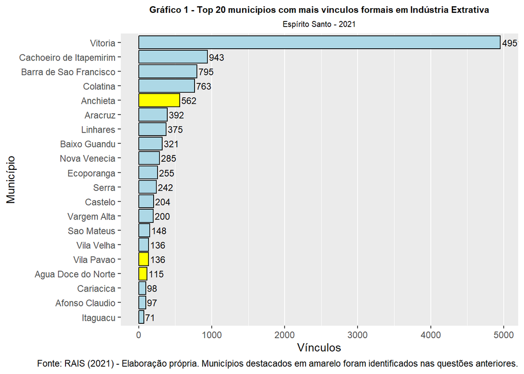

## 2. Caracterize o perfil dos vínculos desse setor para a UF, conforme (a) sexo; (b) idade e (c) escolaridade.

### (a) Caracterização por sexo

Esse cenário indica que a participação feminina permanece bastante limitada, refletindo tanto características históricas do setor — tradicionalmente associado a atividades de maior esforço físico e à presença masculina — quanto barreiras contemporâneas, como menor acesso das mulheres a determinadas formações técnicas, discriminação estrutural e ambientes de trabalho pouco adaptados para diversidade de gênero.

[figure not shown]